# Geog 533 Midterm Exam

Dr. Qiusheng Wu

## What to submit:

An **R notebook/html document** that contains the script/output for each question.File name convention for submissions: lastname_firstname_midterm.zip. You have 60 minutes (8:30-9:30 am) to complete the exam. There will be a 10% penalty per 10 minutes for late submissions.

## Question 1 (20 pt.)

The **iris** data set in the **datasets** package contains 150 cases (rows) and 5 variables (columns).

### Question 1a

Randomly select half of the cases as training dataset and the remaining half as test dataset.

```r
library(datasets)
df <- iris
set.seed(100)
nrow <- nrow(df)
id <- 1:nrow
train.index <- sort(sample(id,size = nrow/2,replace = FALSE))
train.index
```

```
 [1]   9  12  15  20  21  22  24  25  26  27  28  31  32  33  34  37  39  42  45  47  48  51  52  53  55  57
[27]  58  59  64  67  69  70  71  72  75  78  81  82  84  85  86  88  89  91  92  95  96  99 102 103 104 109
[53] 110 111 112 114 117 118 119 120 121 123 124 125 127 129 133 135 137 138 141 143 146 148 149
```

```r
test.index <- id[-train.index]
test.index
```

```
 [1]   1   2   3   4   5   6   7   8  10  11  13  14  16  17  18  19  23  29  30  35  36  38  40  41  43  44
[27]  46  49  50  54  56  60  61  62  63  65  66  68  73  74  76  77  79  80  83  87  90  93  94  97  98 100
[53] 101 105 106 107 108 113 115 116 122 126 128 130 131 132 134 136 139 140 142 144 145 147 150
```

```r
train.df <- df[train.index,]
test.df <- df[test.index,]
if(!(require(DT))) {install.packages("DT")}
library(DT)
datatable(train.df,caption = "Training dataset",options = list(pageLength = 5))
```

|  | Sepal.Length | Sepal.Width | Petal.Length | Petal.Width | Species |
| --- | --- | --- | --- | --- | --- |
| 9 | 4.4 | 2.9 | 1.4 | 0.2 | setosa |
| 12 | 4.8 | 3.4 | 1.6 | 0.2 | setosa |
| 15 | 5.8 | 4 | 1.2 | 0.2 | setosa |
| 20 | 5.1 | 3.8 | 1.5 | 0.3 | setosa |
| 21 | 5.4 | 3.4 | 1.7 | 0.2 | setosa |
| 22 | 5.1 | 3.7 | 1.5 | 0.4 | setosa |
| 24 | 5.1 | 3.3 | 1.7 | 0.5 | setosa |
| 25 | 4.8 | 3.4 | 1.9 | 0.2 | setosa |
| 26 | 5 | 3 | 1.6 | 0.2 | setosa |
| 27 | 5 | 3.4 | 1.6 | 0.4 | setosa |

[output cut: 65 more lines]

```r
datatable(test.df,caption = "Test dataset",options = list(pageLength = 5))
```

|  | Sepal.Length | Sepal.Width | Petal.Length | Petal.Width | Species |
| --- | --- | --- | --- | --- | --- |
| 1 | 5.1 | 3.5 | 1.4 | 0.2 | setosa |
| 2 | 4.9 | 3 | 1.4 | 0.2 | setosa |
| 3 | 4.7 | 3.2 | 1.3 | 0.2 | setosa |
| 4 | 4.6 | 3.1 | 1.5 | 0.2 | setosa |
| 5 | 5 | 3.6 | 1.4 | 0.2 | setosa |
| 6 | 5.4 | 3.9 | 1.7 | 0.4 | setosa |
| 7 | 4.6 | 3.4 | 1.4 | 0.3 | setosa |
| 8 | 5 | 3.4 | 1.5 | 0.2 | setosa |
| 10 | 4.9 | 3.1 | 1.5 | 0.1 | setosa |
| 11 | 5.4 | 3.7 | 1.5 | 0.2 | setosa |

[output cut: 65 more lines]

### Question 1b

Find out the number of each species (*setosa, versicolor, and virginica*) in the training and test datasets, respectively.

```r
table(train.df$Species)
```

```
    setosa versicolor  virginica
        21         27         27
```

```r
table(test.df$Species)
```

```
    setosa versicolor  virginica
        29         23         23
```

## Question 2 (20 pt.)

Assume that the probabilities of boy and girl births are **0.505** and **0.495**, respectively.

### Question 2a

What’s the probability of having exactly 50 boys out of 100 births? **(X = 50)**

```r
answer_2a <- dbinom(50,size = 100,prob = 0.505)
print(answer_2a)
```

```
[1] 0.07919226
```

The answer is **0.0791923**

### Question 2b

What’s the probability of having more than 60 boys out of 100 births? **(X > 60)**

```r
answer_2b <- pbinom(60,size = 100,prob = 0.505,lower.tail = FALSE)
print(answer_2b)
```

```
[1] 0.02241835
```

The answer is **0.0224184**

### Question 2c

What’s the probability of having between 40 and 60 boys out of 100 births? **(40 < X ≤ 60)**

```r
answer_2c <- diff(pbinom(c(40,60),size = 100,prob = 0.505))
print(answer_2c)
```

```
[1] 0.9550539
```

The answer is **0.9550539**

### Question 2d

Plot the density function of the number of boy births out of 100.

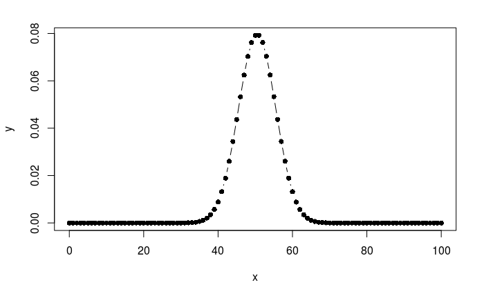

```r
x <- 0:100
y <- dbinom(x,size = 100,prob = 0.505)
plot(x,y,type = "b",pch=16)
```

## Question 3 (20 pt.)

If cars arrive randomly at a traffic light following posission distribution at the rate of five every ten seconds.

### Question 3a

What the probability that exactly 30 cars arrive in the next minute (60 seconds)? (X=30)

```r
answer_3a <- dpois(30,lambda = 5*6)
print(answer_3a)
```

```
[1] 0.07263453
```

The answer is **0.0726345**

### Question 3b

What’s the probability that more than 40 cars arrive in the next minute (60 seconds)? (X>40)

```r
answer_3b <- ppois(40,lambda = 5*6,lower.tail = FALSE)
print(answer_3b)
```

```
[1] 0.03230957
```

The answer is **0.0323096**

### Question 3c

```r
answer_3c <- diff(ppois(c(20,40),lambda = 5*6))
print(answer_3c)
```

```
[1] 0.9324058
```

The answer is **0.9324058**

### Question 3d

Plot the density function of 0-100 cars arriving in the next minute (60 seconds).

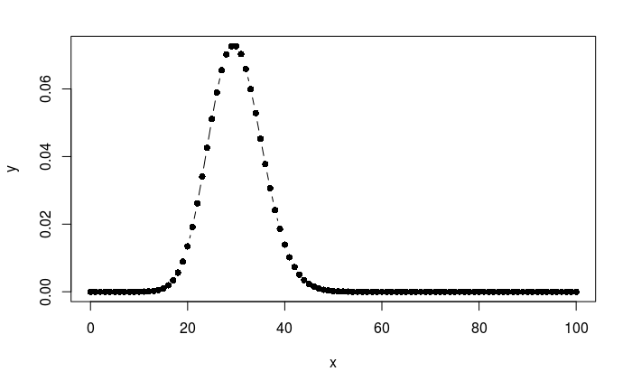

```r
x <- 0:100
y <- dpois(x,lambda = 30)
plot(x,y,type = "b",pch=16)
```

## Question 4 (20 pt.)

The number of customers at a bank each day is found to be normally distributed with mean µ = 250 and standard deviation σ=80.

### Question 4a

What fraction of days will have more than 300 customers? (X>300)

```r
answer_4a <- pnorm(300,mean = 250,sd = 80,lower.tail = FALSE)
print(answer_4a)
```

```
[1] 0.2659855
```

The answer is **0.2659855**

### Question 4b

What number of customers will be exceeded 10% of the time?

```r
answer_4b <- qnorm(0.1,mean = 250,sd = 80,lower.tail = FALSE)
print(answer_4b)
```

```
[1] 352.5241
```

The answer is **352.5241252**

### Question 4c

What fraction of days will have between 200 and 300 customers? (200 < X≤ 300)

```r
answer_4c <- diff(pnorm(c(200,300),mean = 250,sd = 80))
print(answer_4c)
```

```
[1] 0.4680289
```

The answer is **0.4680289**

### Question 4d

Plot the density function and create the shaded area between 200 and 300 customers.

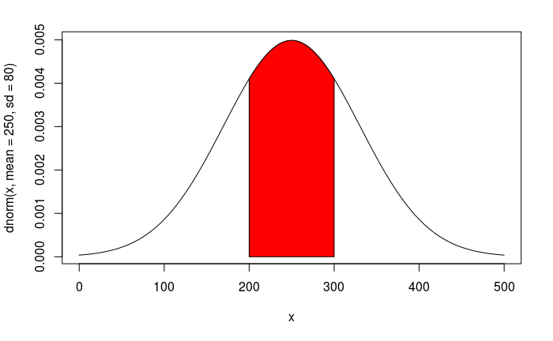

```r
curve(dnorm(x,mean = 250,sd = 80),from = 0,to = 500)
cord.x <- c(200,seq(200,300,by = 1),300)
cord.y <- c(0,dnorm(seq(200,300,by = 1),mean = 250,sd = 80),0)
polygon(cord.x,cord.y,col="red")
```

## Question 5 (20 pt.)

The average time between floods in Binghamton is found to be 4.3 year. Assuming that the distribution of times between floods is exponential. (20 pt.)

**See texbook (Statistical Methods for Geography) page 114**

### Question 5a

What is the likelihood that the time until the next flood will be shorter than one year?

```r
pexp(1, rate = 1/4.3)
```

```
[1] 0.2074963
```

### Question 5b

What is the likelihood that the time until the next flood will be longer than three years?

```r
pexp(3, rate = 1/4.3, lower.tail = FALSE)
```

```
[1] 0.4977415
```

### Question 5c

What is the likelihood that the time until the next flood is between four and seven years?

```r
diff(pexp(c(4,7), rate = 1/4.3))
```

```
[1] 0.1981219
```

### Question 5d

What is the likelihood that time until the next flood is greater than seven years, given that it is greater than four years?

```r
pexp(7, rate = 1/4.3,lower.tail = FALSE) / pexp(4, rate = 1/4.3, lower.tail = FALSE)
```

```
[1] 0.4977415
```